# MR Imaging

## Question 3

When computing the RF signal in the last example, which variable(s) represented the magnetic field gradient?

This is why determining the frequency amplitude of the signal, using the Fourier Transform, is so important: RF signal frequency is associated with spatial position. The amplitude at that frequency can be interpreted as the decay rate.

This simple example provides you with the basic principles of an important MR imaging term: k-space. Specifically, in this example the frequency axis of the Fourier Transform is analogous to k-space.

There are important limitations to the method we have developed up this point.

Mainly, this method works if we only need to make images of an array of beakers along a line. To make estimates of beakers spread across a table top (2D) or filling up a box (3D) we need to do more. These methods will be explained below.

The main difference between this example and general imaging is dimensionality. In MR imaging the stimuli don't fall along one dimension, so we can't simply use a one-dimensional frequency axis to assign position. In general the position in k-space corresponds to a position in a two-dimensional plane that represents various spatial frequencies.

(By the way, there are historical reasons why they call it k-space. I forget these reasons. If someone can remind me, I will give them a firm handshake and a warm smile.)

We will start to extend the ideas on imaging in this first section to slightly more complex cases in the next section.

## Slice position

In nearly all fMRI imaging, the data are acquired using a series of measurements from different planar sections (slices) of the tissue. The measurements are made by selectively exciting the spins, one planar section at a time. If only one plane is excited, then we can be confident that the signal we measure must arise from a voxel in that plane.

In the next part of this tutorial, we will review how we can excite the spins in one planar section. Following that we will review how we can distinguish different positions within the excited plane.

The principles used to understand slice selection are the same as the principles used to distinguish signals from beakers at two positions. The main difference is that in the previous example we used gradients to distinguish received signals. In slice selection we use gradients to selectively deliver an excitation.

The idea is this. We introduce a magnetic field gradient across the sample, which changes the Larmor frequency across the sample. When we deliver an RF pulse at a particular frequency, then only the spins in one portion of the gradient field will be excited.

What would such a pulse look like? Let's create some examples.

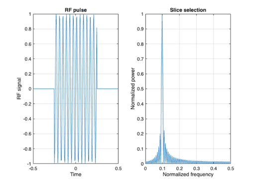

```matlab
% We initialize the rfPulse to
% zero, and then we initialize some parameters.
nTime = 256;  t = (1:nTime)/nTime - 0.5;
rfPulse = zeros(1,nTime);
pulseDuration = round(nTime/2);
pulseStart = nTime/2 - pulseDuration/2;
pulseStop = pulseStart + pulseDuration-1;
pulseT = t((pulseStart:pulseStop));

% We choose a pulse frequency.  This frequency will excite the planar
% section of the tissue that is at the Larmor frequency we wish to excite.
pulseFreq = 25;

% Now, create a sinusoid RF pulse at that frequency.
rfPulse(pulseStart:pulseStop) = sin(2*pi*pulseFreq*pulseT);
figure(1); clf;
subplot(1,2,1), plot(t,rfPulse); xlabel('Time'); ylabel('RF signal');
title('RF pulse'); grid on

% Here is the Fourier Transform spectrum of the RF pulse.
% The frequency content of the pulse determines which plane we excite.
subplot(1,2,2),
[s,f] = powerSpecDens(rfPulse);
plot(f,s); grid on;
xlabel('Normalized frequency'); ylabel('Normalized power');
title('Slice selection')
```

We can control the position that is excited by adjusting the frequency.

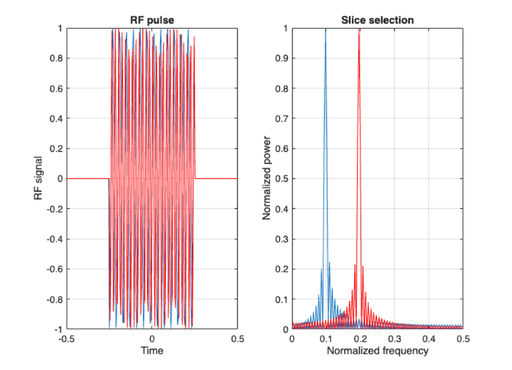

```matlab
pulseFreq = 50;
rfPulse(pulseStart:pulseStop) = sin(2*pi*pulseFreq*pulseT);
subplot(1,2,1), hold on, plot(t,rfPulse, 'r');
xlabel('Time'); ylabel('RF signal'); title('RF pulse')
subplot(1,2,2), hold on
[s,f] = powerSpecDens(rfPulse);
plot(f,s, 'r'); grid on;
xlabel('Normalized frequency'); ylabel('Normalized power');
title('Slice selection')
```

## Slice width

A second parameter we would like to control is the slice width. There are two ways we can adjust the slice width. One way, as described in the book, is to change the gradient. A second way, illustrated here, is to change the timing of the RF pulse.

In this example, we create an RF pulse that is the product of the sinusoid and a sinc function. (Type 'help sinc' to read about this important function). Each sinc function has its own frequency, too.

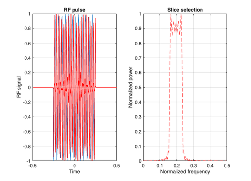

```matlab
sincFreq  = 20;      % Try 10, 20 and 40.
pulseFreq = 50;      % Try 25, 50 and 75.

rfPulse(pulseStart:pulseStop) = sin(2*pi*pulseFreq*pulseT);
rfPulse(pulseStart:pulseStop) = ...
    rfPulse(pulseStart:pulseStop).*sincFunction(sincFreq*pulseT);

hold off;
subplot(1,2,1), plot(t,rfPulse,'r-');
xlabel('Time'); ylabel('RF signal'); title('RF pulse')

hold off;
subplot(1,2,2), [s,f] = powerSpecDens(rfPulse); plot(f,s,'r--'); grid on;
xlabel('Normalized frequency'); ylabel('Normalized power');
title('Slice selection')
```

## Question 4

Run the above code a few times, varying the pulse and sinc frequency values. What effect does each parameter have on slice position and slice width?

## Frequency encoding and phase encoding together

The Hornak MRI book, <http://www.cis.rit.edu/htbooks/mri/ http://www.cis.rit.edu/htbooks/mri/>, has a very good discussion of imaging, including frequency and phase encoding. Please read Chapters 6 and 7 for a useful discussion of the principles further described here. Also, the Huettel et al. book is very clear and useful in describing pulse sequences (Chapters 4 and 5).

Earlier, we reviewed how to use a gradient field to associate different positions along a line with different RF signal frequencies. That method is often called frequency encoding. In this section, we describe how to measure along the second spatial dimension. This measurement is sometimes called the phase-encoding dimension. Taken together, the methods described in this section are sometimes called Fourier Transform imaging.

Consider the problem of identifying signals from 4 beakers placed at the corners of a square. These four beakers are in the planar section and the spins were set in motion using the methods described in the previous section.

First, we set up the basic parameters for the four beakers.

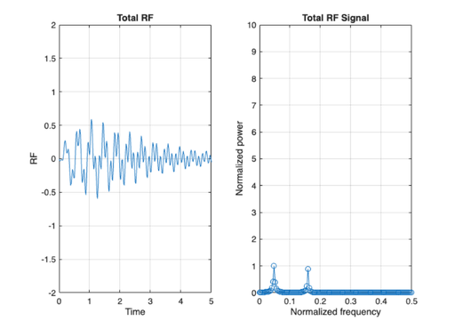

```matlab
clear T1; clear larmorFreq; clear ph; clear signal;
T1 = [1,2;3,4]/2; larmorFreq = [15, 50];
ph = [0, pi]; t = (0:.02:5);
Mo = 1;

rate = [0,0,0,0];
spinDir = [10,0; 10,0; 10,0; 10,0];
figure(1), clf
phaseEncode(rate,spinDir,1,'Gradient-X');
% Apply a gradient across the x-axis (Gx)
% In the presence of this gradient, the signals from the two beakers on the
% left will differ from the RF signals emitted by the two beakers on the right.
% When we measure with only the x-gradient (Gx), we obtain the sum of the two
% beakers on the left in one frequency band and the sum of the two beakers on
% the right in a second frequency band.
%
%

f = [larmorFreq(1),larmorFreq(1),larmorFreq(2), larmorFreq(2)];
p = [ph(1),ph(1),ph(1),ph(1)];
figure(1), clf;
signal = plotRF(f,p,t,T1,Mo,'Gradient-X');

% Total signal
subplot(1,2,1)
s = sum(squeeze(sum(signal,1)),1);
plot(t,s);xlabel('Time'); ylabel('RF'); title('Total RF'); grid on
set(gca,'ylim',[-3 3]);
subplot(1,2,2)
[p,f] = powerSpecDens(s);
plot(f,p,'o-'); grid on; set(gca,'ylim',[0,10]);
xlabel('Normalized frequency'); ylabel('Normalized power');
title('Total RF Signal')
% We turn off Gx and introduce a gradient in the y-dimension (Gy).
% This changes the Larmor frequency of the beakers at the top and bottom of
% the square. Suppose the frequency for the bottom beakers is a little lower.
% Then the spins in the bottom beakers rotate more slowly and they end up pointing
% in a different direction from the spins at the top. After applying Gy for a
% certain amount of time, the spins at the top and bottom will point in opposite
% directions.

rate = [pi/8 pi/8 pi/16 pi/16];
spinDir = [10,0; 10,0; 10,0; 10,0];
figure(1), clf
phaseEncode(rate,spinDir,15,'Gradient-Y');
% Next, we switch off  Gy and turn on Gx.
% As before we will measure the combination of the spins on the left at one
% frequency and the combination of the spins at the right at a different frequency.
% Because the spins of the top and bottom beaker oppose one another, however,
% the total RF signal we obtain now is the difference between the top and bottom.

f = [larmorFreq(1),larmorFreq(1),larmorFreq(2),larmorFreq(2)];
p = [ph(1),ph(2),ph(1),ph(2)];
figure(1), clf; signal = plotRF(f,p,t,T1,Mo,'Gradient-X');

% Total signal
clf; subplot(1,2,1)
s = sum(squeeze(sum(signal,1)),1);
plot(t,s); xlabel('Time'); ylabel('RF'); title('Total RF'); grid on
set(gca,'ylim',[-2 2]);
subplot(1,2,2)
[p,f] = powerSpecDens(s);
plot(f,p,'o-'); grid on; set(gca,'ylim',[0,10]);
xlabel('Normalized frequency'); ylabel('Normalized power');
title('Total RF Signal')
```

In this example, the frequency of the RF signal codes the x-dimension. This dimension is called the frequency dimension. We keep adjusting the phase of the spins along the y-dimension. Hence, this dimension is called the phase-encode dimension. People keep track of these two dimensions because the phase-encode direction is subject to more measurement error than the frequency encode direction.

[Published with MATLAB® R2026a](https://www.mathworks.com/products/matlab/)